# 交叉路口密度 計算方法

Chia-Jung, Yeh

2022-04-27

# 1 **分析流程與資料**

為計算交叉路口密度，須備齊路口經緯度座標資料，以及行政區（如：村里）圖資。將路口資料與行政區進行交集，可瞭解每一路口位於哪一個行政區，接著針對同一行政區統計其路口個數，以及該行政區的面積，並進一步將兩數值相除，即可得該行政區的交叉路口密度。

分析流程依步驟彙整如下：

1. 路口資料與行政區取交集
2. 統計行政區的路口個數
3. 計算各行政區面積與路口密度

計算流程與範例詳如 Figure1.1 所示。

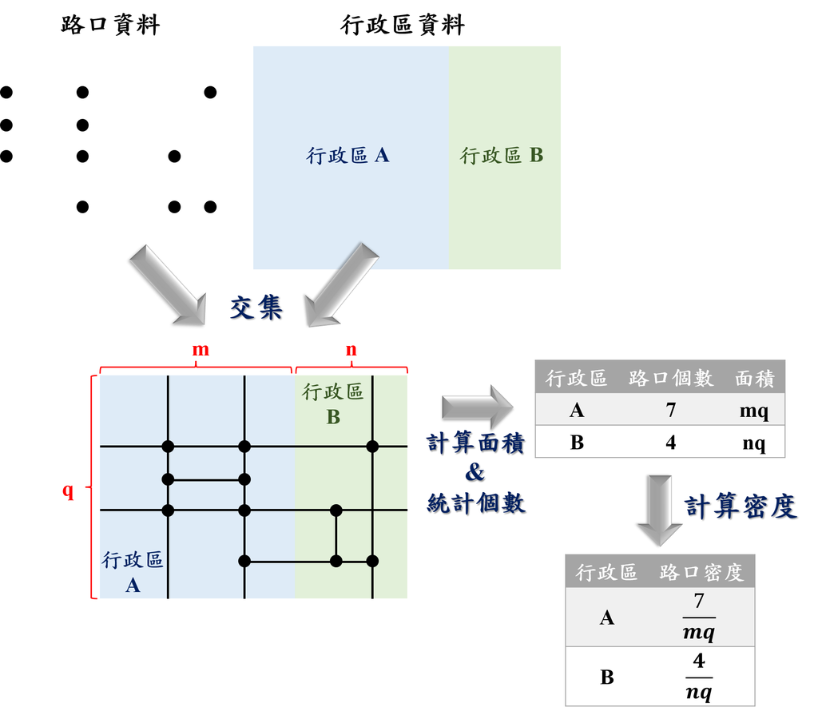

Figure 1.1: 分析流程示意圖

Figure 1.1 中，首先將路口資料與行政資料取交集，分為行政區 A 與行政區 B。接著計算兩塊面積，分別為 $mq$ 與 $nq$。此外亦可統計每一個行政區內擁有的路口數，分別為 7 個與 4 個，故依據上述，密度係將兩者相除，所得結果分別為 $7/mq$ 與 $4/nq$。

依據此一分析流程，後續章節先行介紹地理資訊系統的基礎觀念，並進行實作。

本分析過程所需資料彙整於 Table 1.1 所示。

Table 1.1: 資料來源與下載

[output not shown]

# 2 **地理資訊系統簡介**

## 2.1 WKT

WKT 是為純文本標記格式（Well-known text,WKT），用以表達向量資料的空間位置，而在二維空間中可表示的幾何圖形含括：點（Point）、線（LineString）、面（Polygon）、多點（MultiPoint）、多線（MultiLineString）、多面（MultiPolygon）、幾何集合（GeometryCollection）。在本分析中，我們所使用的路口資料即為「點資料」；村里即為「面資料」。

WKT 的記錄方法如 Table 2.1 所示。

Table 2.1: WKT 撰寫方式

點線面

圖例

WKT

**Point**

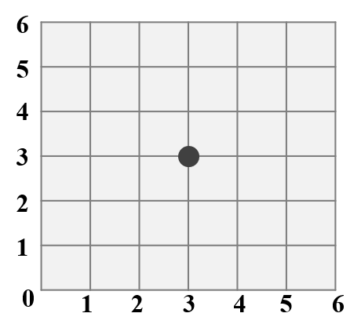

POINT (3 3)

**LineString**

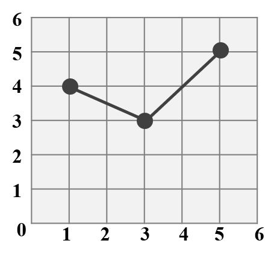

LINESTRING (1 4, 3 3, 5 5)

**Polygon**

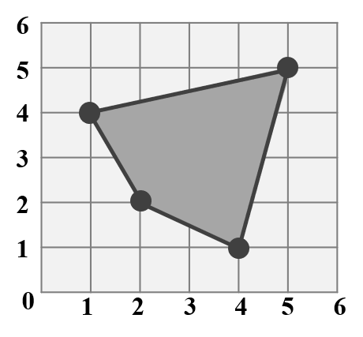

POLYGON ((1 4, 2 2, 4 1, 5 5, 1 4))

本分析所提供的資料中，路口資料即是以 WKT 純文本標記格式儲存。

## 2.2 Shapefile

Shapefile 格式可用以描述（多）點線面，然與 WKT 格式最大不同點在於 Shapefile 無法儲存幾何集合（GeometryCollection），而其應用多以二維平面的空間描述為主。須注意的是，Shapefile 是一種格式名稱，並非檔案名稱，該格式主要由四個檔案所組成，即「.shp」、「.shx」、「.dbf」、「.prj」四者。

Shapefile 的檔案彙整如 Table 2.2 所示。

Table 2.2: Shapefile 檔案類型

[output not shown]

## 2.3 座標參考系統 (CRS)

座標參考系統主要可分為兩大類型：地理座標系統（Geographic Coordinate System, GCS）與投影座標系統（Projected Coordinate System，PCS）。地理座標系統是直接將「經度」定義為「X」、「緯度」定義為「Y」，並且以赤道及本初子午線之交點作為原點，該系統可完整定義全球的座標，但並難以進一步藉此計算面積與距離。投影座標系統為此改善了使用經緯度來定義座標位置的缺失，利用數學方法將地球投影至平面地圖，再依據投影的結果給定原點與座標軸，這麼一來即可定義投影結果上所有點的座標值。

Table 2.3 以簡單範例說明地理座標系統（GCS）與投影座標系統（PCS）的差異。

Table 2.3: 地理與投影座標系統比較

| 座標類型 | 特徵 | 單位 | 臺灣常用EPSG代碼 | 實例（臺北車站） |
| --- | --- | --- | --- | --- |
| 地理座標系統（GCS） | 經緯度座標 | 角度 | EPSG:4326 | (121.51754, 25.04624) |
| 投影座標系統（PCS） | 利用投影所得的平面座標 | 公尺 | EPSG:3826 | (302221.38, 2770999.06) |

## 2.4 R 語言相對應套件

下載`sf`套件，用以處理地理資料，並進行地理資料處理。  
下載`dplyr`套件，用以處理、統計數據。  
下載`ggplot2`套件，用以繪製地圖。

```r
install.packages("sf")
install.packages("dplyr")
install.packages("ggplot2")
library(sf)
library(dplyr)
library(ggplot2)
```

# 3 **分析操作**

本範例以臺北市為例，分析臺北市各個村里的路口密度。

## 3.1 村里資料與路口資料取交集

首先讀取本分析中所需的檔案。

```r
# 從解壓縮後的資料夾中讀取臺北市_IntersectionGeometry.csv
road_inter=read.csv("./intersection_data/臺北市_IntersectionGeometry.csv")

# 查看road_inter前六筆資料
head(road_inter)
```

```
##   TOWNCODE TOWNNAME         RoadList IntersectionList
## 1 63000030   大安區 羅斯福路二段15巷 和平東路一段11巷
## 2 63000030   大安區 羅斯福路二段15巷     羅斯福路二段
## 3 63000030   大安區 羅斯福路二段15巷 羅斯福路二段35巷
## 4 63000030   大安區     杭州南路二段 杭州南路二段25巷
## 5 63000030   大安區     杭州南路二段 杭州南路二段59巷
## 6 63000030   大安區     杭州南路二段 杭州南路二段61巷
##                                IntersectionRoadName
## 1 63000030 羅斯福路二段15巷與和平東路一段11巷交叉口
## 2     63000030 羅斯福路二段15巷與羅斯福路二段交叉口
## 3 63000030 羅斯福路二段15巷與羅斯福路二段35巷交叉口
## 4     63000030 杭州南路二段與杭州南路二段25巷交叉口
## 5     63000030 杭州南路二段與杭州南路二段59巷交叉口
## 6     63000030 杭州南路二段與杭州南路二段61巷交叉口
##                                        Geometry
## 1  POINT (121.5222855457414 25.028323446869649)
## 2 POINT (121.52176769092625 25.028090692431533)
## 3 POINT (121.52229797167411 25.027783380598578)
## 4  POINT (121.5234803247572 25.033934994304616)
## 5 POINT (121.52242401525621 25.031589372651467)
## 6 POINT (121.52217168617449 25.030349498030944)
```

```r
# 從TWspdata套件中使用村里資料
library(TWspdata)

# 查看taiwan_village前六筆資料
head(taiwan_village)
```

```
## Simple feature collection with 6 features and 10 fields
## Geometry type: MULTIPOLYGON
## Dimension:     XY
## Bounding box:  xmin: 119.9089 ymin: 22.42686 xmax: 120.4822 ymax: 26.1561
## Geodetic CRS:  TWD97
## # A tibble: 6 x 11
##   VILLCODE    COUNTYNAME TOWNNAME VILLNAME VILLENG    COUNTYID COUNTYCODE TOWNID
##   <chr>       <chr>      <chr>    <chr>    <chr>      <chr>    <chr>      <chr>
## 1 10013030S01 屏東縣     東港鎮   <NA>     <NA>       T        10013      T03
## 2 64000130006 高雄市     林園區   中門里   Zhongmen ~ E        64000      E13
## 3 64000130008 高雄市     林園區   港埔里   Gangpu Vi~ E        64000      E13
## 4 64000100010 高雄市     旗津區   上竹里   Shangzhu ~ E        64000      E10
## 5 64000100013 高雄市     旗津區   中興里   Zhongxing~ E        64000      E10
## 6 09007010006 連江縣     南竿鄉   津沙村   Jinsha Vi~ Z        09007      Z01
## # ... with 3 more variables: TOWNCODE <chr>, NOTE <chr>,
## #   geometry <MULTIPOLYGON [arc_degree]>
```

接著必須進一步處理我們所蒐集的數據：將全臺的村里資料中擷取臺北市者，並將路口資料中的 WKT 欄位轉換為空間資料。惟須注意的是，由於在交通部所提供的路口資料集中含有許多重複的資料，如「道路 A 與道路 B 交會的路口」以及「道路 B 與道路 A 交會的路口」兩者實屬表達同一個路口，在資料庫中會重複記錄，故必須先行篩除之。

**NOTE**

- 程式碼中利用`st_as_sfc()`函式將 WKT 文字資料轉換為空間資料，相關操作詳見[Spatial Analysis with R (Chia Jung, Yeh) 4.4小節](https://chiajung-yeh.github.io/Spatial-Analysis/geographic-data.html#convert-text-file-to-shapefile)
- 程式碼中利用`st_sf()`函式將純`data.frame`格式新增`sf`格式，可變為完整的地理資料，相關操作詳見[Spatial Analysis with R (Chia Jung, Yeh) 4.3小節](https://chiajung-yeh.github.io/Spatial-Analysis/geographic-data.html#simple-feature-sf)

```r
# 篩選臺北市的村里資料
taipei=filter(taiwan_village, COUNTYNAME=="臺北市")

# 查看taipei前六筆資料
head(taipei)
```

```
## Simple feature collection with 6 features and 10 fields
## Geometry type: MULTIPOLYGON
## Dimension:     XY
## Bounding box:  xmin: 121.553 ymin: 24.96396 xmax: 121.5797 ymax: 24.98516
## Geodetic CRS:  TWD97
## # A tibble: 6 x 11
##   VILLCODE    COUNTYNAME TOWNNAME VILLNAME VILLENG    COUNTYID COUNTYCODE TOWNID
##   <chr>       <chr>      <chr>    <chr>    <chr>      <chr>    <chr>      <chr>
## 1 63000080031 臺北市     文山區   樟新里   Zhangxin ~ A        63000      A11
## 2 63000080037 臺北市     文山區   老泉里   Laoquan V~ A        63000      A11
## 3 63000080032 臺北市     文山區   樟腳里   Zhangjiao~ A        63000      A11
## 4 63000080041 臺北市     文山區   樟文里   Zhangwen ~ A        63000      A11
## 5 63000080043 臺北市     文山區   樟樹里   Zhangshu ~ A        63000      A11
## 6 63000080029 臺北市     文山區   順興里   Shunxing ~ A        63000      A11
## # ... with 3 more variables: TOWNCODE <chr>, NOTE <chr>,
## #   geometry <MULTIPOLYGON [arc_degree]>
```

```r
# 篩選出重複的欄位
repeat_row=which(duplicated(road_inter$Geometry))

# 不重複的欄位
nonrepeat_row=setdiff(c(1:nrow(road_inter)), repeat_row)

# 整理路口資料（篩除重複者）
road_inter=road_inter[nonrepeat_row,]

# 將路口資料的WKT轉換為空間資料
road_inter=mutate(road_inter, Geometry=st_as_sfc(Geometry))%>%
  st_sf(crs=4326)

# 查看road_inter前六筆資料
head(road_inter)
```

```
## Simple feature collection with 6 features and 5 fields
## Geometry type: POINT
## Dimension:     XY
## Bounding box:  xmin: 121.5218 ymin: 25.02778 xmax: 121.5235 ymax: 25.03393
## Geodetic CRS:  WGS 84
##   TOWNCODE TOWNNAME         RoadList IntersectionList
## 1 63000030   大安區 羅斯福路二段15巷 和平東路一段11巷
## 2 63000030   大安區 羅斯福路二段15巷     羅斯福路二段
## 3 63000030   大安區 羅斯福路二段15巷 羅斯福路二段35巷
## 4 63000030   大安區     杭州南路二段 杭州南路二段25巷
## 5 63000030   大安區     杭州南路二段 杭州南路二段59巷
## 6 63000030   大安區     杭州南路二段 杭州南路二段61巷
##                                IntersectionRoadName                  Geometry
## 1 63000030 羅斯福路二段15巷與和平東路一段11巷交叉口 POINT (121.5223 25.02832)
## 2     63000030 羅斯福路二段15巷與羅斯福路二段交叉口 POINT (121.5218 25.02809)
## 3 63000030 羅斯福路二段15巷與羅斯福路二段35巷交叉口 POINT (121.5223 25.02778)
## 4     63000030 杭州南路二段與杭州南路二段25巷交叉口 POINT (121.5235 25.03393)
## 5     63000030 杭州南路二段與杭州南路二段59巷交叉口 POINT (121.5224 25.03159)
## 6     63000030 杭州南路二段與杭州南路二段61巷交叉口 POINT (121.5222 25.03035)
```

先簡單繪圖來觀察兩資料的空間分布，出圖結果如 Figure 3.1 所示。

**NOTE**

- 程式碼中利用`geom_sf()`函式在`ggplot2`套件中繪製地圖，相關操作詳見[Spatial Analysis with R (Chia Jung, Yeh) 3.1小節](https://chiajung-yeh.github.io/Spatial-Analysis/data-visualization-with-maps.html#making-maps)

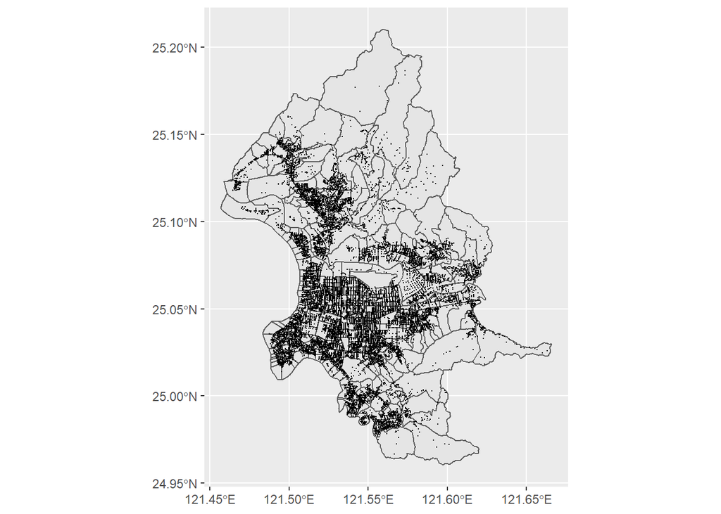

Figure 3.1: 村里與路口資料疊圖結果

```r
# 將村里地圖與路口資料疊圖
ggplot()+
  geom_sf(data=taipei)+
  geom_sf(data=road_inter, size=0.01)
```

接著將路口資料與村里資料利用`st_intersection()`函式取交集，以回傳每一個路口所在的行政區，如此一來尚能在後續分析每一村里中的路口個數。在此務必注意，進行地理資料處理時建議統一所有地理資料的座標參考系統，否則會出現錯誤訊息，抑或出現錯誤的分析結果。

**NOTE**

- 程式碼中利用`st_transform()`函式轉換座標參考系統，相關操作詳見[Spatial Analysis with R (Chia Jung, Yeh) 4.5小節](https://chiajung-yeh.github.io/Spatial-Analysis/geographic-data.html#reproject-geographic-data)
- 程式碼中利用`st_intersection()`函式將兩地理資料取交集，相關操作詳見[Spatial Analysis with R (Chia Jung, Yeh) 5.9小節](https://chiajung-yeh.github.io/Spatial-Analysis/spatial-operations.html#clipping)

```r
# 先將CRS轉換為統一格式，尚能進行交集
# 建議皆轉換為EPSG:3826
taipei=st_transform(taipei, crs=3826)
road_inter=st_transform(road_inter, crs=3826)

# 將村里地圖與路口資料取交集
road_inter=st_intersection(road_inter, taipei[, c("VILLCODE", "COUNTYNAME", "VILLNAME")])
# 查看road_inter交集後結果
head(road_inter)
```

```
## Simple feature collection with 6 features and 8 fields
## Geometry type: POINT
## Dimension:     XY
## Bounding box:  xmin: 305967.6 ymin: 2763456 xmax: 306071.2 ymax: 2763645
## Projected CRS: TWD97 / TM2 zone 121
##      TOWNCODE TOWNNAME     RoadList IntersectionList
## 5281 63000080   文山區   樟新街32巷           樟新街
## 5282 63000080   文山區   樟新街32巷        樟新街8巷
## 5283 63000080   文山區    樟新街8巷           樟新街
## 5285 63000080   文山區    樟新街8巷       樟新街48巷
## 5286 63000080   文山區    樟新街8巷     樟新街8巷5弄
## 5329 63000080   文山區 樟新街8巷5弄       樟新街32巷
##                         IntersectionRoadName    VILLCODE COUNTYNAME VILLNAME
## 5281       63000080 樟新街32巷與樟新街交叉口 63000080031     臺北市   樟新里
## 5282    63000080 樟新街32巷與樟新街8巷交叉口 63000080031     臺北市   樟新里
## 5283        63000080 樟新街8巷與樟新街交叉口 63000080031     臺北市   樟新里
## 5285    63000080 樟新街8巷與樟新街48巷交叉口 63000080031     臺北市   樟新里
## 5286  63000080 樟新街8巷與樟新街8巷5弄交叉口 63000080031     臺北市   樟新里
## 5329 63000080 樟新街8巷5弄與樟新街32巷交叉口 63000080031     臺北市   樟新里
##                      Geometry
## 5281 POINT (306071.2 2763536)
## 5282 POINT (305967.6 2763510)
## 5283 POINT (306038.3 2763645)
## 5285 POINT (305983.5 2763456)
## 5286   POINT (305989 2763631)
## 5329 POINT (306021.1 2763524)
```

透過上述回傳結果可以發現，路口資料中含括路口名稱、路口所在村里。

## 3.2 統計村里的路口個數

接下來即可進一步針對「VILLCODE」（村里代碼）計算屬於同一村里的資料列數，亦即每個村里的路口個數。惟須注意的是，在進行統計時，請務必先行去除原地理資料中的空間欄位，以避免在聚合時，一同將空間進行聚合，而浪費諸多計算時間。

**NOTE**

- 程式碼中利用`st_drop_geometry()`函式將空間欄位予以去除，相關操作詳見[Spatial Analysis with R (Chia Jung, Yeh) 4.8小節](https://chiajung-yeh.github.io/Spatial-Analysis/geographic-data.html#join-attribute-and-spatial-data)
- 程式碼中利用`group_by() %>% summarise()`函式係將一資料針對特定的欄位分群，接著再針對每一分群中進行運算，相關操作詳見[Spatial Analysis with R (Chia Jung, Yeh) 5.2小節](https://chiajung-yeh.github.io/Spatial-Analysis/spatial-operations.html#attribute-aggregation)

```r
# 將路口資料的空間欄位剔除
road_inter_df=st_drop_geometry(road_inter)

# 依據村里名稱與代碼統計其路口個數
road_count=group_by(road_inter_df, TOWNNAME, VILLNAME, VILLCODE)%>%
  summarise(inter_count=n())
```

## 3.3 計算各村里面積與路口密度

目前為止大抵上已完成較複雜的分析，接下來只要針對現有資料中的欄位進行基礎運算即可。在計算路口密度時，除了需要各個村里的路口個數外，尚須計算每一個村里的面積，並且將兩者予以相除，所得結果即為路口密度。在本程式碼中計算完面積後，先將其轉換為平方公里的單位，並且轉換為數值型態。

```r
# 合併路口個數屬性資料與村里地理資料
taipei=left_join(taipei, road_count)
# 計算臺北市各村里的面積
taipei$AREA=as.numeric(st_area(taipei))/1000000

# 計算路口密度
taipei$DENSITY=taipei$inter_count/taipei$AREA

# 查看taipei前六筆資料
head(taipei[ ,c("COUNTYNAME","TOWNNAME","VILLNAME","inter_count","DENSITY")])
```

```
## Simple feature collection with 6 features and 5 fields
## Geometry type: MULTIPOLYGON
## Dimension:     XY
## Bounding box:  xmin: 305833.7 ymin: 2761906 xmax: 308529.2 ymax: 2764253
## Projected CRS: TWD97 / TM2 zone 121
## # A tibble: 6 x 6
##   COUNTYNAME TOWNNAME VILLNAME inter_count DENSITY                      geometry
##   <chr>      <chr>    <chr>          <int>   <dbl>            <MULTIPOLYGON [m]>
## 1 臺北市     文山區   樟新里            33  169.   (((306495.2 2763784, 306502 ~
## 2 臺北市     文山區   老泉里            10    2.65 (((307616.2 2763945, 307636.~
## 3 臺北市     文山區   樟腳里            27  151.   (((307328.8 2764059, 307330.~
## 4 臺北市     文山區   樟文里            39  189.   (((306456.5 2764094, 306465.~
## 5 臺北市     文山區   樟樹里            33  435.   (((306717.5 2764134, 306721 ~
## 6 臺北市     文山區   順興里            34  226.   (((307256.3 2764251, 307443.~
```

由以上結果中以第一列為例，其表示文山區樟新里共計 33 個路口，密度為每平方公里 169.1 個路口。而為了更具視覺化呈現路口密度結果，可繪製地圖如 Figure 3.2 所示。

**NOTE**

- 程式碼中利用`geom_sf()`函式在`ggplot2`套件中繪製分層設色地圖，相關操作詳見[Spatial Analysis with R (Chia Jung, Yeh) 3.4小節](https://chiajung-yeh.github.io/Spatial-Analysis/data-visualization-with-maps.html#graduated-symbol-map)

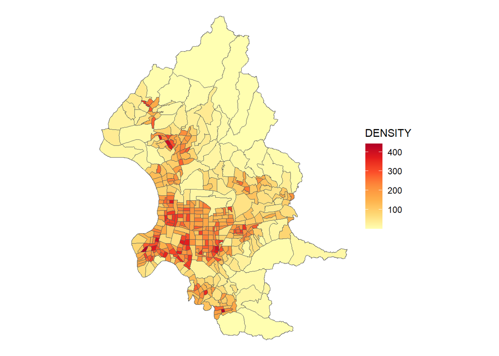

Figure 3.2: 臺北市各村里路口密度

```r
# 繪製地圖
ggplot()+
  geom_sf(data=taipei, aes(fill=DENSITY), size=0.01)+
  scale_fill_distiller(palette="YlOrRd", direction=1)+
  theme_void()
```